# MiDAS tutorial

Maciej Migdał & Christian Hammer

2020-11-19

[figure not shown]

## Introduction

Welcome to MiDAS. This tutorial is supposed to help you get started with your analyses of immunogenetic associations. We will work with a simulated data set of 500 patients and 500 controls with a binary disease diagnosis.

We also have high resolution HLA alleles (4 - 6 digit), and presence/absence calls for KIR genes.

## Data import and sanity check

First, let’s import the phenotype data and HLA calls using MiDAS import functions. MiDAS will check for correct nomenclature of HLA. We can also define 4-digit resolution for HLA alleles as import format, which means that alleles with higher resolution will be reduced.

```r
dat_pheno <-
  read.table(
  file = system.file("extdata", "MiDAS_tut_pheno.txt", package = "MiDAS"),
  header = TRUE
  )
dat_HLA <-
  readHlaCalls(
  file = system.file("extdata", "MiDAS_tut_HLA.txt", package = "MiDAS"),
  resolution = 4
  )
```

Let’s take a look at the imported HLA data tables:

HLA data as imported by MiDAS

| ID | A_1 | A_2 | B_1 | B_2 | C_1 | C_2 | DPA1_1 | DPA1_2 | DPB1_1 | DPB1_2 | DQA1_1 | DQA1_2 | DQB1_1 | DQB1_2 | DRA_1 | DRA_2 | DRB1_1 | DRB1_2 |
| --- | --- | --- | --- | --- | --- | --- | --- | --- | --- | --- | --- | --- | --- | --- | --- | --- | --- | --- |
| C001 | A*25:01 | A*26:01 | B*07:02 | B*18:01 | C*12:03 | C*07:02 | DPA1*01:03 | DPA1*01:03 | DPB1*02:01 | DPB1*04:01 | DQA1*05:05 | DQA1*01:02 | DQB1*06:02 | DQB1*03:01 | DRA*01:02 | DRA*01:02 | DRB1*15:01 | DRB1*12:01 |
| C002 | A*02:01 | A*02:324 | B*50:01 | B*18:01 | C*06:02 | C*12:03 | DPA1*01:03 | DPA1*01:03 | DPB1*04:02 | DPB1*04:02 | DQA1*02:01 | DQA1*05:05 | DQB1*02:02 | DQB1*03:01 | DRA*01:01 | DRA*01:01 | DRB1*07:01 | DRB1*11:04 |
| C003 | A*24:02 | A*24:04 | B*46:01 | B*40:06 | C*01:03 | C*15:02 | DPA1*02:02 | DPA1*02:01 | DPB1*05:01 | DPB1*14:01 | DQA1*01:04 | DQA1*01:03 | DQB1*06:01 | DQB1*05:02 | DRA*01:02 | DRA*01:01 | DRB1*14:07 | DRB1*08:03 |
| C004 | A*01:01 | A*24:02 | B*08:01 | B*15:01 | C*07:01 | C*03:03 | DPA1*01:03 | DPA1*01:03 | DPB1*04:01 | DPB1*03:01 | DQA1*01:03 | DQA1*01:02 | DQB1*06:04 | DQB1*06:03 | DRA*01:02 | DRA*01:01 | DRB1*13:01 | DRB1*13:02 |
| C005 | A*01:01 | A*25:01 | B*18:01 | B*08:01 | C*12:03 | C*07:01 | DPA1*01:03 | DPA1*01:03 | DPB1*04:01 | DPB1*23:01 | DQA1*05:01 | DQA1*01:02 | DQB1*02:01 | DQB1*06:02 | DRA*01:02 | DRA*01:02 | DRB1*03:01 | DRB1*15:01 |
| C006 | A*03:01 | A*01:01 | B*07:02 | B*08:01 | C*07:01 | C*07:02 | DPA1*01:03 | DPA1*01:03 | DPB1*57:01 | DPB1*271:01 | DQA1*01:02 | DQA1*01:01 | DQB1*06:04 | DQB1*05:01 | DRA*01:01 | DRA*01:02 | DRB1*13:02 | DRB1*01:02 |
| C007 | A*01:01 | A*02:01 | B*15:01 | B*08:01 | C*07:01 | C*03:03 | DPA1*02:01 | DPA1*01:03 | DPB1*04:02 | DPB1*13:01 | DQA1*05:01 | DQA1*03:01 | DQB1*02:01 | DQB1*03:02 | DRA*01:01 | DRA*01:02 | DRB1*03:01 | DRB1*04:01 |
| C008 | A*11:01 | A*02:01 | B*35:01 | B*27:05 | C*03:04 | C*04:01 | DPA1*01:03 | DPA1*01:03 | DPB1*04:01 | DPB1*04:01 | DQA1*03:03 | DQA1*01:02 | DQB1*06:04 | DQB1*03:01 | DRA*01:02 | DRA*01:01 | DRB1*13:02 | DRB1*04:01 |
| C009 | A*23:01 | A*01:01 | B*13:02 | B*18:01 | C*07:01 | C*07:02 | DPA1*02:01 | DPA1*01:03 | DPB1*01:01 | DPB1*04:02 | DQA1*05:05 | DQA1*03:01 | DQB1*03:01 | DQB1*03:02 | DRA*01:01 | DRA*01:01 | DRB1*11:04 | DRB1*04:03 |
| C010 | A*31:01 | A*02:06 | B*15:01 | B*56:01 | C*04:01 | C*03:03 | DPA1*02:02 | DPA1*02:02 | DPB1*05:01 | DPB1*05:01 | DQA1*03:02 | DQA1*03:02 | DQB1*03:03 | DQB1*03:96 | DRA*01:01 | DRA*01:01 | DRB1*09:01 | DRB1*09:01 |
| C011 | A*02:01 | A*01:01 | B*07:02 | B*13:02 | C*06:02 | C*07:02 | DPA1*02:01 | DPA1*02:01 | DPB1*17:01 | DPB1*10:01 | DQA1*02:01 | DQA1*01:01 | DQB1*02:02 | DQB1*05:01 | DRA*01:01 | DRA*01:01 | DRB1*07:01 | DRB1*01:01 |
| C012 | A*02:01 | A*02:01 | B*15:01 | B*27:02 | C*02:02 | C*03:03 | DPA1*01:03 | DPA1*01:03 | DPB1*04:01 | DPB1*04:01 | DQA1*01:02 | DQA1*03:01 | DQB1*03:02 | DQB1*05:02 | DRA*01:01 | DRA*01:01 | DRB1*04:04 | DRB1*16:01 |
| C013 | A*02:05 | A*01:01 | B*49:01 | B*57:01 | C*07:01 | C*07:01 | DPA1*01:03 | DPA1*01:03 | DPB1*04:01 | DPB1*04:01 | DQA1*02:01 | DQA1*03:03 | DQB1*03:02 | DQB1*03:03 | DRA*01:01 | DRA*01:01 | DRB1*04:05 | DRB1*07:01 |
| C014 | A*30:02 | A*01:01 | B*37:01 | B*27:05 | C*06:02 | C*02:02 | DPA1*02:01 | DPA1*01:03 | DPB1*02:01 | DPB1*10:01 | DQA1*03:01 | DQA1*03:03 | DQB1*04:02 | DQB1*03:02 | DRA*01:01 | DRA*01:01 | DRB1*04:03 | DRB1*04:04 |
| C015 | A*02:642 | A*03:01 | B*07:02 | B*07:02 | C*07:02 | C*07:02 | DPA1*01:03 | DPA1*01:03 | DPB1*04:01 | DPB1*16:01 | DQA1*01:02 | DQA1*01:02 | DQB1*06:02 | DQB1*06:02 | DRA*01:02 | DRA*01:02 | DRB1*15:01 | DRB1*15:01 |
| C016 | A*01:01 | A*68:01 | B*42:01 | B*08:156 | C*07:02 | C*07:01 | DPA1*01:03 | DPA1*01:03 | DPB1*04:01 | DPB1*02:01 | DQA1*05:01 | DQA1*01:02 | DQB1*02:01 | DQB1*06:02 | DRA*01:02 | DRA*01:02 | DRB1*03:01 | DRB1*15:01 |
| C017 | A*03:01 | A*11:01 | B*08:01 | B*18:01 | C*05:01 | C*07:01 | DPA1*02:01 | DPA1*01:03 | DPB1*04:01 | DPB1*01:01 | DQA1*05:01 | DQA1*05:01 | DQB1*02:01 | DQB1*02:01 | DRA*01:01 | DRA*01:02 | DRB1*03:01 | DRB1*03:01 |
| C018 | A*11:01 | A*02:01 | B*15:01 | B*37:01 | C*06:02 | C*04:01 | DPA1*01:03 | DPA1*02:02 | DPB1*04:01 | DPB1*05:01 | DQA1*01:03 | DQA1*01:05 | DQB1*06:01 | DQB1*05:01 | DRA*01:01 | DRA*01:02 | DRB1*10:01 | DRB1*08:03 |
| C019 | A*02:10 | A*31:01 | B*54:01 | B*40:06 | C*08:01 | C*01:02 | DPA1*02:02 | DPA1*01:03 | DPB1*04:02 | DPB1*05:01 | DQA1*03:02 | DQA1*03:01 | DQB1*04:01 | DQB1*03:96 | DRA*01:01 | DRA*01:01 | DRB1*09:01 | DRB1*04:05 |
| C020 | A*01:01 | A*29:02 | B*44:03 | B*08:01 | C*07:01 | C*16:01 | DPA1*02:01 | DPA1*02:02 | DPB1*01:01 | DPB1*10:01 | DQA1*02:01 | DQA1*05:01 | DQB1*02:01 | DQB1*02:02 | DRA*01:02 | DRA*01:01 | DRB1*07:01 | DRB1*03:01 |

MiDAS comes with some pre-defined reference populations, but it is possible to customize these comparisons (see documentation).

```r
freq_HLA <- getHlaFrequencies(hla_calls = dat_HLA, compare = TRUE) %>%
  filter(Freq > 0.01)
```

HLA frequencies, compared to published references

| allele | Counts | Freq | USA NMDP African American pop 2 | USA NMDP Chinese | USA NMDP European Caucasian | USA NMDP Hispanic South or Central American | USA NMDP Japanese | USA NMDP North American Amerindian | USA NMDP South Asian Indian |
| --- | --- | --- | --- | --- | --- | --- | --- | --- | --- |
| A*25:01 | 52 | 0.0260 | 0.0034 | 0.0002 | 0.0210 | 0.0101 | 0.0007 | 0.0148 | 0.0001 |
| A*26:01 | 90 | 0.0450 | 0.0146 | 0.0237 | 0.0309 | 0.0295 | 0.0798 | 0.0199 | 0.0418 |
| B*07:02 | 152 | 0.0760 | 0.0729 | 0.0079 | 0.1306 | 0.0584 | 0.0588 | 0.1005 | 0.0440 |
| B*18:01 | 129 | 0.0645 | 0.0320 | 0.0026 | 0.0443 | 0.0411 | 0.0021 | 0.0323 | 0.0252 |
| C*07:02 | 219 | 0.1095 | 0.0713 | 0.1944 | 0.1413 | 0.1214 | 0.1218 | 0.1510 | 0.1078 |
| C*12:03 | 142 | 0.0710 | 0.0149 | 0.0176 | 0.0486 | 0.0415 | 0.0019 | 0.0265 | 0.0491 |

Let’s assume our cohort is of predominantly European ancestry. We can plot the following comparison to see if allele frequencies in our data are distributed as expected, for example by visualizing common HLA-A allele frequencies in comparison with European, Chinese, and African American reference populations:

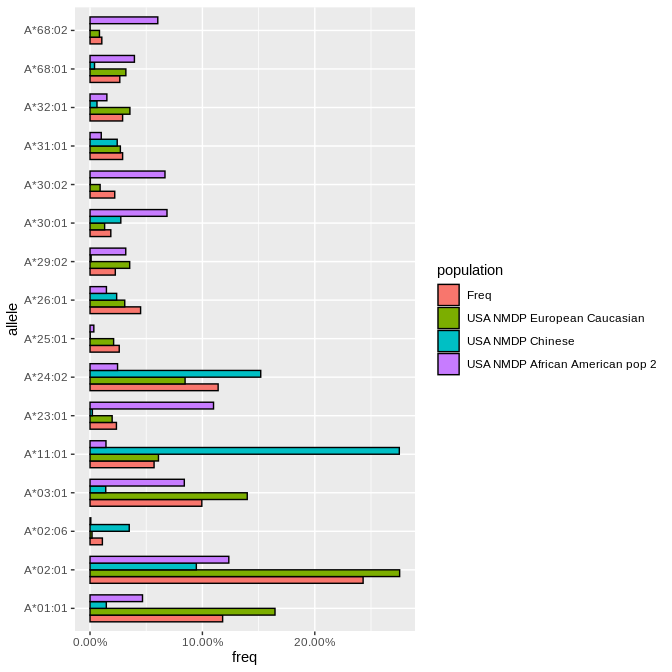

```r
freq_HLA_long <- gather(
  data = freq_HLA,
  key = "population",
  value = "freq",
  "Freq",
  "USA NMDP European Caucasian",
  "USA NMDP Chinese",
  "USA NMDP African American pop 2",
  factor_key = TRUE
) %>%
  filter(grepl("^A", allele))

plot_HLAfreq <-
  ggplot(data = freq_HLA_long, aes(x = allele, y = freq, fill = population)) +
  geom_bar(
    stat = "identity",
    position = position_dodge(0.7),
    width = 0.7,
    colour = "black"
  ) +
  coord_flip() +
  scale_y_continuous(labels = formattable::percent)

plot_HLAfreq
```

## HLA association analysis

### Are classical HLA alleles associated with disease status?

The following function prepares our data for analysis, combining HLA and phenotypic data into one object. Here, we are interested in analyzing our data on the level of **classical HLA alleles**.

```r
HLA <- prepareMiDAS(
  hla_calls = dat_HLA,
  colData = dat_pheno,
  experiment = "hla_alleles"
)
```

We can now test our HLA data for deviations from Hardy-Weinberg-Equilibrium (HWE) to filter out alleles that strongly deviate from HWE expectations (imputation or genotyping errors, …). Here, let’s remove alleles with a HWE p-value below 0.05 divided by the number of alleles tested / present in our data (N=447). We can create a filtered MiDAS object right away (`as.MiDAS = TRUE`), as done in this example, or output actual HWE test results.

```r
HLA <- HWETest(
  object = HLA,
  experiment = "hla_alleles",
  HWE_cutoff = 0.05 / 447,
  as.MiDAS = TRUE
)
```

Now, we define our statistical model and run the analysis. Since we want to test for association with disease status, we use a logistic regression approach. The `term` is necessary as placeholder for the tested HLA alleles and needs to be included. It will become handy when for example defining more complex interaction models.

In the `runMiDAS` function, we then refer to this model, choose our analysis type and define a inheritance model. Here we use dominant model, meaning that individuals will be defined as non-carriers (0) vs. carriers (1) for a given allele. Alternatively, it is also possible to choose recessive (0 = non-carrier or heterozygous carrier, 1 = homozygous carrier), overdominant (assuming heterozygous (dis)advantage: 0 = non-carrier or homozygous carrier, 1 = heterozygous carrier), or additive (N of alleles) inheritance models. Moreover, we define allele inclusion criteria, such that we only consider alleles frequencies above 2% and below 98%. We also apply the *Bonferroni* method to not only get nominal P values, but also such adjusted for multiple testing. For alternative multiple testing correction methods, as well as the option to choose a custom number of tests, please refer to the documentation. `exponentiate = TRUE` means that the effect estimate will already be shown as odds ratio, since we use a logistic regression model.

```r
HLA_model <- glm(disease ~ term, data = HLA, family = binomial())
HLA_results <- runMiDAS(
  object = HLA_model,
  experiment = "hla_alleles",
  inheritance_model = "dominant",
  lower_frequency_cutoff = 0.02,
  upper_frequency_cutoff = 0.98,
  correction = "bonferroni",
  exponentiate = TRUE
)

kableResults(HLA_results)
```

| MiDAS analysis results allele | MiDAS analysis results p.value | MiDAS analysis results p.adjusted | MiDAS analysis results estimate | MiDAS analysis results std.error | MiDAS analysis results conf.low | MiDAS analysis results conf.high | MiDAS analysis results statistic | MiDAS analysis results Ntotal | MiDAS analysis results Ntotal [%] | MiDAS analysis results N(disease=0) | MiDAS analysis results N(disease=0) [%] | MiDAS analysis results N(disease=1) | MiDAS analysis results N(disease=1) [%] |
| --- | --- | --- | --- | --- | --- | --- | --- | --- | --- | --- | --- | --- | --- |
| DQB1*06:02 | 2,600e-06 | 2,290e-04 | 2,1719 | 0,1651 | 1,5764 | 3,0138 | 4,698e+00 | 198 | 9,90% | 69 | 6,90% | 129 | 12,90% |
| DRB1*15:01 | 7,300e-06 | 6,386e-04 | 2,0649 | 0,1617 | 1,5081 | 2,8450 | 4,484e+00 | 206 | 10,30% | 74 | 7,40% | 132 | 13,20% |
| B*57:01 | 3,080e-05 | 2,682e-03 | 2,9931 | 0,2631 | 1,8157 | 5,1189 | 4,167e+00 | 79 | 3,95% | 21 | 2,10% | 58 | 5,80% |
| C*07:02 | 1,859e-04 | 1,618e-02 | 1,8227 | 0,1606 | 1,3334 | 2,5044 | 3,737e+00 | 204 | 10,20% | 78 | 7,80% | 126 | 12,60% |
| B*18:01 | 6,012e-04 | 5,230e-02 | 0,5014 | 0,2012 | 0,3357 | 0,7400 | -3,431e+00 | 122 | 6,10% | 79 | 7,90% | 43 | 4,30% |
| DRA*01:02 | 2,701e-03 | 2,350e-01 | 1,4703 | 0,1285 | 1,1435 | 1,8926 | 3,000e+00 | 573 | 28,65% | 263 | 26,30% | 310 | 31,00% |
| DQB1*02:02 | 4,569e-03 | 3,975e-01 | 0,6257 | 0,1654 | 0,4513 | 0,8635 | -2,836e+00 | 185 | 9,25% | 110 | 11,00% | 75 | 7,50% |
| B*51:01 | 4,863e-03 | 4,231e-01 | 1,7271 | 0,1941 | 1,1849 | 2,5396 | 2,816e+00 | 128 | 6,40% | 49 | 4,90% | 79 | 7,90% |
| DRA*01:01 | 1,073e-02 | 9,331e-01 | 0,6210 | 0,1867 | 0,4289 | 0,8930 | -2,552e+00 | 862 | 43,10% | 445 | 44,50% | 417 | 41,70% |
| B*44:02 | 2,068e-02 | 1,000e+00 | 1,4963 | 0,1742 | 1,0655 | 2,1111 | 2,314e+00 | 161 | 8,05% | 67 | 6,70% | 94 | 9,40% |
| C*08:02 | 2,076e-02 | 1,000e+00 | 1,8030 | 0,2549 | 1,1023 | 3,0076 | 2,312e+00 | 71 | 3,55% | 26 | 2,60% | 45 | 4,50% |
| DQA1*04:01 | 2,235e-02 | 1,000e+00 | 1,9179 | 0,2851 | 1,1089 | 3,4120 | 2,284e+00 | 57 | 2,85% | 20 | 2,00% | 37 | 3,70% |
| DQB1*05:02 | 3,106e-02 | 1,000e+00 | 0,5645 | 0,2652 | 0,3313 | 0,9417 | -2,156e+00 | 65 | 3,25% | 41 | 4,10% | 24 | 2,40% |
| DRB1*11:01 | 3,188e-02 | 1,000e+00 | 0,6651 | 0,1900 | 0,4565 | 0,9630 | -2,146e+00 | 131 | 6,55% | 77 | 7,70% | 54 | 5,40% |
| DRB1*07:01 | 3,518e-02 | 1,000e+00 | 0,7266 | 0,1517 | 0,5390 | 0,9772 | -2,106e+00 | 228 | 11,40% | 128 | 12,80% | 100 | 10,00% |
| A*31:01 | 6,065e-02 | 1,000e+00 | 1,6857 | 0,2784 | 0,9846 | 2,9492 | 1,876e+00 | 58 | 2,90% | 22 | 2,20% | 36 | 3,60% |
| B*08:01 | 8,299e-02 | 1,000e+00 | 0,7130 | 0,1951 | 0,4847 | 1,0431 | -1,734e+00 | 122 | 6,10% | 70 | 7,00% | 52 | 5,20% |
| DQA1*01:02 | 9,218e-02 | 1,000e+00 | 1,2555 | 0,1351 | 0,9637 | 1,6371 | 1,684e+00 | 327 | 16,35% | 151 | 15,10% | 176 | 17,60% |
| B*07:02 | 1,037e-01 | 1,000e+00 | 1,3456 | 0,1825 | 0,9424 | 1,9292 | 1,627e+00 | 142 | 7,10% | 62 | 6,20% | 80 | 8,00% |
| B*35:01 | 1,043e-01 | 1,000e+00 | 0,6811 | 0,2365 | 0,4254 | 1,0787 | -1,624e+00 | 80 | 4,00% | 47 | 4,70% | 33 | 3,30% |
| DQB1*04:02 | 1,069e-01 | 1,000e+00 | 1,5610 | 0,2762 | 0,9141 | 2,7147 | 1,612e+00 | 58 | 2,90% | 23 | 2,30% | 35 | 3,50% |
| DRB1*03:01 | 1,102e-01 | 1,000e+00 | 0,7737 | 0,1606 | 0,5639 | 1,0592 | -1,597e+00 | 194 | 9,70% | 107 | 10,70% | 87 | 8,70% |
| DQA1*02:01 | 1,177e-01 | 1,000e+00 | 0,7913 | 0,1496 | 0,5895 | 1,0604 | -1,565e+00 | 235 | 11,75% | 128 | 12,80% | 107 | 10,70% |
| C*03:03 | 1,291e-01 | 1,000e+00 | 0,6974 | 0,2374 | 0,4349 | 1,1070 | -1,518e+00 | 79 | 3,95% | 46 | 4,60% | 33 | 3,30% |
| C*07:01 | 1,309e-01 | 1,000e+00 | 0,7952 | 0,1517 | 0,5901 | 1,0700 | -1,511e+00 | 226 | 11,30% | 123 | 12,30% | 103 | 10,30% |
| DQB1*02:01 | 1,314e-01 | 1,000e+00 | 0,7860 | 0,1596 | 0,5740 | 1,0739 | -1,509e+00 | 197 | 9,85% | 108 | 10,80% | 89 | 8,90% |
| DPB1*104:01 | 1,341e-01 | 1,000e+00 | 0,6295 | 0,3089 | 0,3380 | 1,1441 | -1,498e+00 | 46 | 2,30% | 28 | 2,80% | 18 | 1,80% |
| DQA1*01:01 | 1,613e-01 | 1,000e+00 | 1,2610 | 0,1656 | 0,9122 | 1,7473 | 1,401e+00 | 179 | 8,95% | 81 | 8,10% | 98 | 9,80% |
| DQB1*03:01 | 1,699e-01 | 1,000e+00 | 0,8355 | 0,1309 | 0,6461 | 1,0797 | -1,373e+00 | 373 | 18,65% | 197 | 19,70% | 176 | 17,60% |
| A*02:01 | 1,796e-01 | 1,000e+00 | 1,1874 | 0,1280 | 0,9241 | 1,5265 | 1,342e+00 | 427 | 21,35% | 203 | 20,30% | 224 | 22,40% |

[output cut: 57 more lines]

```r
HLA_results_cond <- runMiDAS(
  object = HLA_model,
  experiment = "hla_alleles",
  inheritance_model = "dominant",
  conditional = TRUE,
  lower_frequency_cutoff = 0.02,
  upper_frequency_cutoff = 0.98,
  correction = "bonferroni",
  exponentiate = TRUE
)

kableResults(HLA_results_cond, scroll_box_height = "200px")
```

| MiDAS analysis results allele | MiDAS analysis results p.value | MiDAS analysis results p.adjusted | MiDAS analysis results estimate | MiDAS analysis results std.error | MiDAS analysis results conf.low | MiDAS analysis results conf.high | MiDAS analysis results statistic | MiDAS analysis results covariates | MiDAS analysis results Ntotal | MiDAS analysis results Ntotal [%] | MiDAS analysis results N(disease=0) | MiDAS analysis results N(disease=0) [%] | MiDAS analysis results N(disease=1) | MiDAS analysis results N(disease=1) [%] |
| --- | --- | --- | --- | --- | --- | --- | --- | --- | --- | --- | --- | --- | --- | --- |
| DQB1*06:02 | 2,60e-06 | 2,290e-04 | 2,172 | 0,1651 | 1,576 | 3,014 | 4,698 |  | 198 | 9,90% | 69 | 6,90% | 129 | 12,90% |
| B*57:01 | 2,64e-05 | 2,269e-03 | 3,049 | 0,2653 | 1,841 | 5,235 | 4,203 | DQB1*06:02 | 79 | 3,95% | 21 | 2,10% | 58 | 5,80% |

The results for conditional testing are displayed in a way that for each step the top associated allele is shown, along with a list of alleles conditioned on.

As we can see, *HLA-DRB1*15:01* was not independently associated with the disease when correcting for our top-associated allele *HLA-DQB1*06:02*. However, *HLA-B*57:01* can be considered an independent association signal.

## HLA association fine-mapping on amino acid level

Next, we want to find out what are the strongest associated amino acid positions, corresponding to our allele-level associations. This can help fine-mapping the associated variants to e.g. the peptide binding region or other functionally distinct parts of the protein. We thus prepare a MiDAS object with experiment type “hla_aa”, which includes the inference of amino acid variation from allele calls.

```r
HLA_AA <- prepareMiDAS(
  hla_calls = dat_HLA,
  colData = dat_pheno,
  experiment = "hla_aa"
)
```

Amino acid data will be stored in a MiDAS object, but we can extract it to a data frame and select a couple of variables to display how this looks like:

```r
dat_HLA_AA <- HLA_AA[["hla_aa"]] %>%
  assay() %>%
  t() %>%
  as.data.frame() %>%
  select(starts_with("B_97_")) %>%
  head()
```

HLA amino acid data as inferred by MiDAS

|  | B_97_S | B_97_R | B_97_T | B_97_N | B_97_V | B_97_W |
| --- | --- | --- | --- | --- | --- | --- |
| C001 | 1 | 1 | 0 | 0 | 0 | 0 |
| C002 | 0 | 2 | 0 | 0 | 0 | 0 |
| C003 | 0 | 1 | 1 | 0 | 0 | 0 |
| C004 | 1 | 1 | 0 | 0 | 0 | 0 |
| C005 | 1 | 1 | 0 | 0 | 0 | 0 |
| C006 | 2 | 0 | 0 | 0 | 0 | 0 |

Now, we run the association test based on amino acid variation. To first identify the most relevant associated amino acid positions, we run a likelihood ratio (omnibus) test, which groups all residues at each amino acid position.

```r
HLA_AA_model <- glm(disease ~ term, data = HLA_AA, family = binomial())
HLA_AA_omnibus_results <- runMiDAS(
  HLA_AA_model,
  experiment = "hla_aa",
  conditional = FALSE,
  omnibus = TRUE,
  lower_frequency_cutoff = 0.02,
  upper_frequency_cutoff = 0.98,
  correction = "bonferroni"
)

kableResults(HLA_AA_omnibus_results)
```

| MiDAS analysis results aa_pos | MiDAS analysis results residues | MiDAS analysis results df | MiDAS analysis results statistic | MiDAS analysis results p.value | MiDAS analysis results p.adjusted |
| --- | --- | --- | --- | --- | --- |
| B_97 | S, R, T, N, V, W | 5 | 3,303e+01 | 3,700e-06 | 1,293e-03 |
| DQB1_9 | F, Y, L | 2 | 2,173e+01 | 1,910e-05 | 6,677e-03 |
| B_81 | L, A | 1 | 1,586e+01 | 6,830e-05 | 2,384e-02 |
| B_82 | R, L | 1 | 1,514e+01 | 9,960e-05 | 3,477e-02 |
| B_83 | G, R | 1 | 1,514e+01 | 9,960e-05 | 3,477e-02 |
| B_62 | R, G | 1 | 1,503e+01 | 1,056e-04 | 3,687e-02 |
| DRB1_-1 | S, A | 2 | 1,723e+01 | 1,814e-04 | 6,330e-02 |
| B_65 | Q, R | 1 | 1,384e+01 | 1,989e-04 | 6,941e-02 |
| B_80 | N, T, I | 2 | 1,650e+01 | 2,613e-04 | 9,121e-02 |
| B_77 | S, N, D | 3 | 1,841e+01 | 3,615e-04 | 1,262e-01 |
| B_30 | D, G | 1 | 1,269e+01 | 3,680e-04 | 1,284e-01 |
| B_70 | Q, N, K, S | 3 | 1,760e+01 | 5,308e-04 | 1,852e-01 |
| DRA_217 | L, V | 1 | 1,173e+01 | 6,145e-04 | 2,145e-01 |
| DQB1_77 | T, R | 1 | 1,169e+01 | 6,268e-04 | 2,187e-01 |
| B_66 | I, N | 2 | 1,461e+01 | 6,725e-04 | 2,347e-01 |
| DRB1_71 | A, R, E, K | 3 | 1,710e+01 | 6,750e-04 | 2,356e-01 |
| B_282 | V, I | 2 | 1,447e+01 | 7,218e-04 | 2,519e-01 |
| B_9 | Y, H, D | 2 | 1,404e+01 | 8,959e-04 | 3,127e-01 |
| DQB1_38 | A, V | 1 | 1,060e+01 | 1,131e-03 | 3,946e-01 |
| C_99 | Y, C, F, S | 3 | 1,594e+01 | 1,168e-03 | 4,076e-01 |
| B_67 | Y, S, F, C, M | 4 | 1,806e+01 | 1,200e-03 | 4,189e-01 |
| B_326 | C, S | 2 | 1,316e+01 | 1,391e-03 | 4,855e-01 |
| B_306 | A, T | 2 | 1,295e+01 | 1,541e-03 | 5,378e-01 |
| DQB1_87 | F, L, Y | 2 | 1,288e+01 | 1,597e-03 | 5,575e-01 |
| B_103 | V, L | 2 | 1,251e+01 | 1,918e-03 | 6,694e-01 |
| DQB1_125 | G, A, S | 2 | 1,251e+01 | 1,922e-03 | 6,707e-01 |
| B_71 | A, T | 1 | 9,352e+00 | 2,228e-03 | 7,775e-01 |
| DQB1_-18 | V, A | 2 | 1,166e+01 | 2,937e-03 | 1,000e+00 |
| DRB1_133 | L, R | 2 | 1,141e+01 | 3,335e-03 | 1,000e+00 |
| DRB1_142 | M, V | 2 | 1,141e+01 | 3,335e-03 | 1,000e+00 |

[output cut: 319 more lines]

Next, we can investigate how effect estimates are distributed for a given associated amino acid position, e.g. DQB1_9:

```r
HLA_AA_DQB1_9_results <- runMiDAS(
  HLA_AA_model,
  experiment = "hla_aa",
  omnibus_groups_filter = "DQB1_9",
  lower_frequency_cutoff = 0.02,
  upper_frequency_cutoff = 0.98,
  correction = "bonferroni",
  exponentiate = TRUE
)

kableResults(HLA_AA_DQB1_9_results, scroll_box_height = "250px")
```

| MiDAS analysis results aa | MiDAS analysis results p.value | MiDAS analysis results p.adjusted | MiDAS analysis results estimate | MiDAS analysis results std.error | MiDAS analysis results conf.low | MiDAS analysis results conf.high | MiDAS analysis results statistic | MiDAS analysis results Ntotal | MiDAS analysis results Ntotal [%] | MiDAS analysis results N(disease=0) | MiDAS analysis results N(disease=0) [%] | MiDAS analysis results N(disease=1) | MiDAS analysis results N(disease=1) [%] |
| --- | --- | --- | --- | --- | --- | --- | --- | --- | --- | --- | --- | --- | --- |
| DQB1_9_F | 6,200e-06 | 1,85e-05 | 1,7929 | 0,1291 | 1,3956 | 2,3166 | 4,5204 | 302 | 15,10% | 114 | 11,40% | 188 | 18,80% |
| DQB1_9_Y | 1,110e-05 | 3,32e-05 | 0,5908 | 0,1197 | 0,4661 | 0,7455 | -4,3955 | 1649 | 82,45% | 863 | 86,30% | 786 | 78,60% |
| DQB1_9_L | 6,734e-01 | 1,00e+00 | 1,1261 | 0,2818 | 0,6478 | 1,9728 | 0,4214 | 49 | 2,45% | 23 | 2,30% | 26 | 2,60% |

This shows us that individuals carrying a Phenylalanine (F) at position 9 of DQB1 have a significantly increased risk, whereas individuals carrying a Tyrosine (Y) at the same amino acid position have a decreased risk.

It is logical to hypothesize that the risk residue is found on *HLA-DQB1*06:02*, the previously associated HLA risk allele. MiDAS thus provides the function `getAllelesforAA` to map amino acid residues back to the respective HLA alleles.

```r
HLA_AA_DQB1_9_alleles <- getAllelesForAA(HLA_AA,"DQB1_9")
```

| HLA-DQB1 (9) | HLA-DQB1 alleles | count | frequency |
| --- | --- | --- | --- |
| F | *04:01,* 04:02, *04:23,* 06:02 | 302 | 15,10% |
| L | *06:01 | 49 | 2,45% |
| Y | *02:01,* 02:02, *02:10,* 03:01, *03:02,* 03:03, *03:04,* 03:05, *03:19,* 03:22, *03:251,* 03:96, *05:01,* 05:02, *05:03,* 05:04, *05:107,* 06:03, *06:04,* 06:07, *06:09 | 1649 | 82,45% |

Finally, it is also interesting to note that there are several amino acid positions coming up that determine the Bw4 binding motif (e.g. B_81), which is a determinant for interactions of HLA class I alleles with KIR on Natural Killer cells.

### Can we find evidence for a role of HLA variation related to NK cell interactions?

Let’s assume outcome differences in our disease of interest have been shown to be related to NK cell biology. HLA class I alleles can be grouped according to how they interact with KIR, expressed on NK cells. We here now prepare a new MiDAS object, grouping HLA alleles into categories defining their interactions with KIRs (**Bw4 vs. Bw6, C1 vs. C2**). Then we test these variables for association with disease outcome:

```r
NKlig <- prepareMiDAS(
  hla_calls = dat_HLA,
  colData = dat_pheno,
  experiment = c("hla_alleles", "hla_NK_ligands")
)
```

```r
NKlig_model <- glm(disease ~ term, data = NKlig, family = binomial())
NKlig_results <- runMiDAS(
  NKlig_model,
  experiment = "hla_NK_ligands",
  inheritance_model = "dominant",
  correction = "bonferroni",
  exponentiate = TRUE
)

kableResults(NKlig_results)
```

| MiDAS analysis results allele.group | MiDAS analysis results p.value | MiDAS analysis results p.adjusted | MiDAS analysis results estimate | MiDAS analysis results std.error | MiDAS analysis results conf.low | MiDAS analysis results conf.high | MiDAS analysis results statistic | MiDAS analysis results Ntotal | MiDAS analysis results Ntotal [%] | MiDAS analysis results N(disease=0) | MiDAS analysis results N(disease=0) [%] | MiDAS analysis results N(disease=1) | MiDAS analysis results N(disease=1) [%] |
| --- | --- | --- | --- | --- | --- | --- | --- | --- | --- | --- | --- | --- | --- |
| Bw6 | 4,249e-04 | 2,549e-03 | 0,5747 | 0,1572 | 0,4213 | 0,7806 | -3,524 | 786 | 39,30% | 416 | 41,60% | 370 | 37,00% |
| Bw6 (HLA-B only) | 4,249e-04 | 2,549e-03 | 0,5747 | 0,1572 | 0,4213 | 0,7806 | -3,524 | 786 | 39,30% | 416 | 41,60% | 370 | 37,00% |
| Bw4 | 1,051e-03 | 6,307e-03 | 1,6877 | 0,1597 | 1,2363 | 2,3140 | 3,276 | 796 | 39,80% | 377 | 37,70% | 419 | 41,90% |
| Bw4 (HLA-B only) | 6,713e-03 | 4,028e-02 | 1,4482 | 0,1366 | 1,1087 | 1,8947 | 2,711 | 682 | 34,10% | 321 | 32,10% | 361 | 36,10% |
| C1 | 9,438e-02 | 5,663e-01 | 1,3257 | 0,1685 | 0,9537 | 1,8482 | 1,673 | 828 | 41,40% | 404 | 40,40% | 424 | 42,40% |
| C2 | 1,000e+00 | 1,000e+00 | 1,0000 | 0,1313 | 0,7730 | 1,2936 | 0,000 | 634 | 31,70% | 317 | 31,70% | 317 | 31,70% |

We find that *HLA-Bw6* and *HLA-Bw4* carrier status are associated with decreased and increased disease risk, respectively. Of course, this is interesting enough for us to invest in some KIR typing efforts.

## KIR associations and HLA-KIR interactions

### Do we see association on the level of KIR genes, and when considering defined HLA-KIR interactions?

Now that we have performed KIR genotyping, or e.g. inferred KIR types from available whole-genome sequencing data, we can import this information, and check the gene frequencies. In our example, we could successfully infer KIR gene presence status for 935 out of the 1,000 individuals in our data set.

```r
dat_KIR <- readKirCalls(
  file = system.file("extdata", "MiDAS_tut_KIR.txt", package = "MiDAS")
)
```

KIR data as imported by MiDAS

| ID | KIR3DL3 | KIR2DS2 | KIR2DL2 | KIR2DL3 | KIR2DP1 | KIR2DL1 | KIR3DP1 | KIR2DL4 | KIR3DL1 | KIR3DS1 | KIR2DL5 | KIR2DS3 | KIR2DS5 | KIR2DS4 | KIR2DS1 | KIR3DL2 |
| --- | --- | --- | --- | --- | --- | --- | --- | --- | --- | --- | --- | --- | --- | --- | --- | --- |
| C001 | 1 | 0 | 0 | 1 | 1 | 1 | 1 | 1 | 1 | 0 | 0 | 0 | 0 | 1 | 0 | 1 |
| C002 | 1 | 0 | 0 | 1 | 1 | 1 | 1 | 1 | 1 | 0 | 0 | 0 | 0 | 1 | 0 | 1 |
| C003 | 1 | 0 | 0 | 1 | 1 | 1 | 1 | 1 | 0 | 1 | 1 | 0 | 1 | 0 | 1 | 1 |
| C004 | 1 | 0 | 0 | 1 | 1 | 1 | 1 | 1 | 0 | 1 | 1 | 0 | 1 | 0 | 1 | 1 |
| C005 | 1 | 0 | 0 | 1 | 1 | 1 | 1 | 1 | 1 | 1 | 1 | 0 | 1 | 1 | 1 | 1 |
| C006 | 1 | 0 | 0 | 1 | 1 | 1 | 1 | 1 | 1 | 0 | 0 | 0 | 0 | 1 | 0 | 1 |
| C007 | 1 | 0 | 0 | 1 | 1 | 1 | 1 | 1 | 1 | 0 | 0 | 0 | 0 | 1 | 0 | 1 |
| C008 | 1 | 0 | 0 | 1 | 1 | 1 | 1 | 1 | 1 | 0 | 0 | 0 | 0 | 1 | 0 | 1 |
| C009 | 1 | 1 | 1 | 0 | 1 | 1 | 1 | 1 | 0 | 1 | 1 | 1 | 1 | 0 | 1 | 1 |
| C010 | 1 | 1 | 1 | 1 | 1 | 1 | 1 | 1 | 0 | 1 | 1 | 0 | 1 | 0 | 1 | 1 |
| C011 | NA | NA | NA | NA | NA | NA | NA | NA | NA | NA | NA | NA | NA | NA | NA | NA |
| C012 | 1 | 1 | 1 | 1 | 1 | 1 | 1 | 1 | 0 | 1 | 1 | 1 | 1 | 0 | 1 | 1 |
| C013 | 1 | 1 | 1 | 1 | 1 | 0 | 1 | 1 | 0 | 1 | 1 | 0 | 1 | 0 | 1 | 1 |
| C014 | 1 | 1 | 1 | 1 | 1 | 1 | 1 | 1 | 0 | 1 | 1 | 1 | 1 | 0 | 1 | 1 |
| C015 | NA | NA | NA | NA | NA | NA | NA | NA | NA | NA | NA | NA | NA | NA | NA | NA |
| C016 | 1 | 0 | 0 | 1 | 1 | 1 | 1 | 1 | 0 | 1 | 1 | 0 | 1 | 0 | 1 | 1 |
| C017 | 1 | 1 | 1 | 1 | 1 | 1 | 1 | 1 | 0 | 1 | 1 | 0 | 1 | 0 | 1 | 1 |
| C018 | 1 | 0 | 0 | 1 | 1 | 1 | 1 | 1 | 0 | 1 | 1 | 1 | 1 | 0 | 1 | 1 |
| C019 | 1 | 0 | 0 | 1 | 1 | 1 | 1 | 1 | 0 | 1 | 1 | 0 | 1 | 0 | 1 | 1 |
| C020 | 1 | 1 | 1 | 1 | 1 | 1 | 1 | 1 | 0 | 1 | 1 | 0 | 1 | 0 | 1 | 1 |
| C021 | 1 | 1 | 1 | 1 | 1 | 1 | 1 | 1 | 0 | 1 | 1 | 1 | 1 | 0 | 1 | 1 |
| C022 | 1 | 1 | 1 | 1 | 1 | 1 | 1 | 1 | 0 | 1 | 1 | 1 | 1 | 0 | 1 | 1 |
| C023 | 1 | 1 | 1 | 1 | 1 | 1 | 1 | 1 | 0 | 1 | 1 | 1 | 1 | 0 | 1 | 1 |
| C024 | 1 | 1 | 1 | 1 | 1 | 1 | 1 | 1 | 0 | 1 | 1 | 1 | 1 | 0 | 1 | 1 |
| C025 | 1 | 1 | 1 | 1 | 1 | 1 | 1 | 1 | 0 | 1 | 1 | 1 | 1 | 0 | 1 | 1 |
| C026 | NA | NA | NA | NA | NA | NA | NA | NA | NA | NA | NA | NA | NA | NA | NA | NA |
| C027 | 1 | 1 | 1 | 0 | 1 | 1 | 1 | 1 | 0 | 1 | 1 | 1 | 1 | 0 | 1 | 1 |
| C028 | 1 | 1 | 1 | 0 | 1 | 1 | 1 | 1 | 0 | 1 | 1 | 1 | 1 | 0 | 1 | 1 |
| C029 | 1 | 0 | 0 | 1 | 1 | 1 | 1 | 1 | 0 | 1 | 1 | 1 | 1 | 0 | 1 | 1 |
| C030 | 1 | 1 | 1 | 1 | 1 | 1 | 1 | 1 | 0 | 1 | 1 | 0 | 1 | 0 | 1 | 1 |

[output cut: 970 more lines]

Next, we want to check our KIR genes frequencies.

```r
kir_freq <- getKIRFrequencies(dat_KIR)
```

KIR data as imported by MiDAS

| gene | Counts | Freq |
| --- | --- | --- |
| KIR3DL3 | 935 | 1,0000000 |
| KIR2DS2 | 455 | 0,4866310 |
| KIR2DL2 | 449 | 0,4802139 |
| KIR2DL3 | 849 | 0,9080214 |
| KIR2DP1 | 925 | 0,9893048 |
| KIR2DL1 | 918 | 0,9818182 |
| KIR3DP1 | 935 | 1,0000000 |
| KIR2DL4 | 935 | 1,0000000 |
| KIR3DL1 | 853 | 0,9122995 |
| KIR3DS1 | 365 | 0,3903743 |
| KIR2DL5 | 485 | 0,5187166 |
| KIR2DS3 | 294 | 0,3144385 |
| KIR2DS5 | 288 | 0,3080214 |
| KIR2DS4 | 853 | 0,9122995 |
| KIR2DS1 | 371 | 0,3967914 |
| KIR3DL2 | 935 | 1,0000000 |

Next, we rerun our `prepareMiDAS` function, this time including the KIR data. We prepare the data to test for both KIR gene associations, as well as HLA-KIR interactions. But first, let’s `runMiDAS` on the level of KIR genes.

```r
HLAKIR <- prepareMiDAS(
  hla_calls = dat_HLA,
  kir_calls = dat_KIR,
  colData = dat_pheno,
  experiment = c("hla_NK_ligands","kir_genes", "hla_kir_interactions")
)
KIR_model <- glm(disease ~ term, data = HLAKIR, family = binomial())
KIR_results <- runMiDAS(
  KIR_model,
  experiment = "kir_genes",
  lower_frequency_cutoff = 0.02,
  upper_frequency_cutoff = 0.98,
  exponentiate = TRUE
)

kableResults(KIR_results)
```

| MiDAS analysis results kir.gene | MiDAS analysis results p.value | MiDAS analysis results p.adjusted | MiDAS analysis results estimate | MiDAS analysis results std.error | MiDAS analysis results conf.low | MiDAS analysis results conf.high | MiDAS analysis results statistic | MiDAS analysis results Ntotal | MiDAS analysis results Ntotal [%] | MiDAS analysis results N(disease=0) | MiDAS analysis results N(disease=0) [%] | MiDAS analysis results N(disease=1) | MiDAS analysis results N(disease=1) [%] |
| --- | --- | --- | --- | --- | --- | --- | --- | --- | --- | --- | --- | --- | --- |
| KIR3DL1 | 3,700e-06 | 3,650e-05 | 3,4291 | 0,2661 | 2,0717 | 5,9126 | 4,6303 | 853 | 91,23% | 405 | 86,72% | 448 | 95,73% |
| KIR2DS4 | 3,700e-06 | 3,650e-05 | 3,4291 | 0,2661 | 2,0717 | 5,9126 | 4,6303 | 853 | 91,23% | 405 | 86,72% | 448 | 95,73% |
| KIR2DL3 | 4,414e-02 | 4,414e-01 | 0,6282 | 0,2310 | 0,3965 | 0,9835 | -2,0128 | 849 | 90,80% | 433 | 92,72% | 416 | 88,89% |
| KIR2DS2 | 8,295e-02 | 8,295e-01 | 1,2552 | 0,1311 | 0,9710 | 1,6235 | 1,7338 | 455 | 48,66% | 214 | 45,82% | 241 | 51,50% |
| KIR2DL2 | 1,087e-01 | 1,000e+00 | 1,2341 | 0,1311 | 0,9546 | 1,5962 | 1,6043 | 449 | 48,02% | 212 | 45,40% | 237 | 50,64% |
| KIR2DS5 | 1,143e-01 | 1,000e+00 | 0,7992 | 0,1420 | 0,6046 | 1,0552 | -1,5790 | 288 | 30,80% | 155 | 33,19% | 133 | 28,42% |
| KIR2DS3 | 1,658e-01 | 1,000e+00 | 1,2160 | 0,1411 | 0,9224 | 1,6044 | 1,3858 | 294 | 31,44% | 137 | 29,34% | 157 | 33,55% |
| KIR2DS1 | 1,949e-01 | 1,000e+00 | 0,8407 | 0,1338 | 0,6465 | 1,0927 | -1,2962 | 371 | 39,68% | 195 | 41,76% | 176 | 37,61% |
| KIR3DS1 | 7,178e-01 | 1,000e+00 | 0,9527 | 0,1341 | 0,7324 | 1,2391 | -0,3614 | 365 | 39,04% | 185 | 39,61% | 180 | 38,46% |
| KIR2DL5 | 9,208e-01 | 1,000e+00 | 0,9871 | 0,1309 | 0,7636 | 1,2759 | -0,0994 | 485 | 51,87% | 243 | 52,03% | 242 | 51,71% |

We found an association of KIR3DL1 gene presence with disease status. Since HLA alleles encoding Bw4 epitopes are ligands for KIR3DL1, we can now ask the question whether patients coding for both receptor and ligand are at increased risk for our disease phenotype.

## HLA-KIR interactions

### Do known biological interactions between KIR receptors and their HLA ligands show significant assocation?

If both HLA alleles and KIR gene presence / absence information is available, MiDAS can encode experimentally validated receptor-ligand interactions, defined according to [Pende et al](https://www.ncbi.nlm.nih.gov/pmc/articles/PMC6558367/). Please note that there is extensive allelic variation in KIR genes, as well as evidence that their interaction with HLA does not only depend on the presence of the KIR gene, but also allele status. Currently, MiDAS does not consider allelic variation in KIR, but a custom dictionary can be provided by the user (see documentation).

First let’s explore HLA-KIR interactions frequencies

```r
hlakir_freq <- getFrequencies(HLAKIR, experiment = "hla_kir_interactions")
```

HLA-KIR interaction frequencies

| term | Counts | Freq |
| --- | --- | --- |
| C2_KIR2DL1 | 580 | 0,6079665 |
| C1_KIR2DL2 | 373 | 0,3922187 |
| B*46:01_KIR2DL2 | 4 | 0,0040000 |
| B*73:01_KIR2DL2 | 0 | 0,0000000 |
| C2_KIR2DL2 | 283 | 0,2966457 |
| C1_KIR2DL3 | 704 | 0,7402734 |
| B*46:01_KIR2DL3 | 10 | 0,0100000 |
| B*73:01_KIR2DL3 | 2 | 0,0020000 |
| C2_KIR2DL3 | 537 | 0,5628931 |
| A*23_KIR3DL1 | 36 | 0,0363269 |
| A*24_KIR3DL1 | 196 | 0,1983806 |
| A*32_KIR3DL1 | 54 | 0,0541625 |
| A*03_KIR3DL2 | 189 | 0,1926606 |
| A*11_KIR3DL2 | 116 | 0,1161161 |
| Bw4_KIR3DL1 | 680 | 0,7188161 |
| Bw4(HLA-B_only)_KIR3DL1 | 585 | 0,6138510 |
| C2_KIR2DS1 | 237 | 0,2484277 |
| C1_KIR2DS2 | 379 | 0,3985279 |
| A*11:01_KIR2DS2 | 48 | 0,0480480 |
| C*02:02_KIR2DS4 | 76 | 0,0763052 |
| C*04:01_KIR2DS4 | 180 | 0,1832994 |
| C*05:01_KIR2DS4 | 122 | 0,1238579 |
| C*01:02_KIR2DS4 | 85 | 0,0855131 |
| C*14:02_KIR2DS4 | 28 | 0,0280280 |
| C*16:01_KIR2DS4 | 42 | 0,0421264 |
| A*11_KIR2DS4 | 102 | 0,1021021 |
| C2_KIR2DS5 | 178 | 0,1865828 |
| B*51_KIR3DS1 | 53 | 0,0532663 |

```r
HLAKIR_model <- glm(disease ~ term, data = HLAKIR, family = binomial())
HLA_KIR_results <- runMiDAS(
  HLAKIR_model,
  experiment = "hla_kir_interactions",
  lower_frequency_cutoff = 0.02,
  upper_frequency_cutoff = 0.98,
  exponentiate = TRUE
)

kableResults(HLA_KIR_results)
```

| MiDAS analysis results hla.kir.interaction | MiDAS analysis results p.value | MiDAS analysis results p.adjusted | MiDAS analysis results estimate | MiDAS analysis results std.error | MiDAS analysis results conf.low | MiDAS analysis results conf.high | MiDAS analysis results statistic | MiDAS analysis results Ntotal | MiDAS analysis results Ntotal [%] | MiDAS analysis results N(disease=0) | MiDAS analysis results N(disease=0) [%] | MiDAS analysis results N(disease=1) | MiDAS analysis results N(disease=1) [%] |
| --- | --- | --- | --- | --- | --- | --- | --- | --- | --- | --- | --- | --- | --- |
| Bw4_KIR3DL1 | 6,000e-07 | 1,560e-05 | 2,0952 | 0,1487 | 1,5686 | 2,810 | 4,976e+00 | 680 | 71,88% | 306 | 64,56% | 374 | 79,24% |
| Bw4(HLA-B_only)_KIR3DL1 | 6,240e-05 | 1,497e-03 | 1,7131 | 0,1345 | 1,3173 | 2,232 | 4,004e+00 | 585 | 61,39% | 262 | 55,04% | 323 | 67,71% |
| C1_KIR2DS2 | 1,895e-03 | 4,547e-02 | 1,5127 | 0,1332 | 1,1656 | 1,966 | 3,106e+00 | 379 | 39,85% | 167 | 34,94% | 212 | 44,82% |
| C1_KIR2DL2 | 2,877e-03 | 6,905e-02 | 1,4889 | 0,1336 | 1,1466 | 1,936 | 2,981e+00 | 373 | 39,22% | 165 | 34,52% | 208 | 43,97% |
| B*51_KIR3DS1 | 1,801e-02 | 4,322e-01 | 2,0202 | 0,2973 | 1,1427 | 3,692 | 2,365e+00 | 53 | 5,33% | 18 | 3,61% | 35 | 7,04% |
| A*24_KIR3DL1 | 1,111e-01 | 1,000e+00 | 1,2909 | 0,1602 | 0,9437 | 1,770 | 1,593e+00 | 196 | 19,84% | 88 | 17,81% | 108 | 21,86% |
| C2_KIR2DS5 | 1,352e-01 | 1,000e+00 | 0,7793 | 0,1669 | 0,5610 | 1,080 | -1,494e+00 | 178 | 18,66% | 98 | 20,55% | 80 | 16,77% |
| C2_KIR2DS1 | 1,549e-01 | 1,000e+00 | 0,8076 | 0,1502 | 0,6011 | 1,084 | -1,422e+00 | 237 | 24,84% | 128 | 26,83% | 109 | 22,85% |
| A*11_KIR3DL2 | 1,712e-01 | 1,000e+00 | 0,7618 | 0,1988 | 0,5143 | 1,123 | -1,368e+00 | 116 | 11,61% | 65 | 13,00% | 51 | 10,22% |
| A*11:01_KIR2DS2 | 2,415e-01 | 1,000e+00 | 0,7038 | 0,2999 | 0,3862 | 1,260 | -1,171e+00 | 48 | 4,80% | 28 | 5,60% | 20 | 4,01% |
| A*03_KIR3DL2 | 3,149e-01 | 1,000e+00 | 1,1771 | 0,1622 | 0,8568 | 1,619 | 1,005e+00 | 189 | 19,27% | 88 | 18,00% | 101 | 20,53% |
| C*02:02_KIR2DS4 | 3,498e-01 | 1,000e+00 | 1,2515 | 0,2399 | 0,7832 | 2,013 | 9,351e-01 | 76 | 7,63% | 34 | 6,84% | 42 | 8,42% |
| A*11_KIR2DS4 | 4,096e-01 | 1,000e+00 | 0,8413 | 0,2096 | 0,5563 | 1,268 | -8,245e-01 | 102 | 10,21% | 55 | 11,00% | 47 | 9,42% |
| C*05:01_KIR2DS4 | 4,465e-01 | 1,000e+00 | 1,1590 | 0,1938 | 0,7931 | 1,698 | 7,613e-01 | 122 | 12,39% | 57 | 11,59% | 65 | 13,18% |
| C2_KIR2DL3 | 4,728e-01 | 1,000e+00 | 0,9105 | 0,1306 | 0,7048 | 1,176 | -7,179e-01 | 537 | 56,29% | 274 | 57,44% | 263 | 55,14% |
| A*32_KIR3DL1 | 5,709e-01 | 1,000e+00 | 0,8530 | 0,2806 | 0,4890 | 1,478 | -5,668e-01 | 54 | 5,42% | 29 | 5,82% | 25 | 5,01% |
| C*04:01_KIR2DS4 | 5,996e-01 | 1,000e+00 | 1,0905 | 0,1650 | 0,7891 | 1,508 | 5,250e-01 | 180 | 18,33% | 87 | 17,68% | 93 | 18,98% |
| C2_KIR2DL2 | 6,198e-01 | 1,000e+00 | 1,0729 | 0,1418 | 0,8126 | 1,417 | 4,961e-01 | 283 | 29,66% | 138 | 28,93% | 145 | 30,40% |
| C*01:02_KIR2DS4 | 7,047e-01 | 1,000e+00 | 1,0898 | 0,2270 | 0,6982 | 1,705 | 3,790e-01 | 85 | 8,55% | 41 | 8,22% | 44 | 8,89% |
| C*14:02_KIR2DS4 | 7,057e-01 | 1,000e+00 | 0,8649 | 0,3843 | 0,4012 | 1,840 | -3,777e-01 | 28 | 2,80% | 15 | 3,00% | 13 | 2,61% |
| A*23_KIR3DL1 | 7,483e-01 | 1,000e+00 | 1,1153 | 0,3401 | 0,5717 | 2,193 | 3,209e-01 | 36 | 3,63% | 17 | 3,44% | 19 | 3,82% |
| C*16:01_KIR2DS4 | 7,576e-01 | 1,000e+00 | 1,1023 | 0,3157 | 0,5928 | 2,061 | 3,086e-01 | 42 | 4,21% | 20 | 4,02% | 22 | 4,41% |
| C2_KIR2DL1 | 8,945e-01 | 1,000e+00 | 0,9826 | 0,1326 | 0,7575 | 1,274 | -1,326e-01 | 580 | 60,80% | 291 | 61,01% | 289 | 60,59% |
| C1_KIR2DL3 | 9,824e-01 | 1,000e+00 | 0,9967 | 0,1479 | 0,7458 | 1,332 | -2,209e-02 | 704 | 74,03% | 354 | 74,06% | 350 | 74,00% |

Patients who are carriers of both *HLA-Bw4* and *KIR3DL1* are at a significantly increased risk for having the disease, which is consistent with the associations we saw on KIR ligand and KIR gene level.

Finally, let’s now take a look at some additional ways to analyze immunogenetics data within MiDAS, which are probably not relevant for most users.

## HLA heterozygosity and evolutionary divergence

Instead of focusing on single HLA alleles or their interactions, you might be interested in HLA diversity. For example, it has been shown that [MHC heterozygosity confers a selective advantage](https://www.pnas.org/content/99/17/11260) against infections with multiple *Salmonella* strains. But given the degree of variability in HLA genes, heterozygosity is a rather crude measure. On the amino acid sequence level, it is possible to perform more refined analyses, by calculating the level of evolutionary divergence between pairs of HLA alleles of different genes. [Pierini and Lenz](https://academic.oup.com/mbe/article/35/9/2145/5034935) have found Grantham’s distance score to be a good proxy for HLA functional divergence. It has been demonstrated that *HLA-C* allelic divergence was associated with [HIV viral load](https://academic.oup.com/mbe/article/37/3/639/5607306). In addition, there is evidence for a role of HLA class I divergence in the [efficacy of cancer immunotherapy](https://www.nature.com/articles/s41591-019-0639-4).

MiDAS provides experiment types `hla_het` to analyze heterozygosity of class I and II genes, as well as `hla_divergence` to analyze classical class I genes using Grantham’s distance:

```r
HLA_het <- prepareMiDAS(
  hla_calls = dat_HLA,
  colData = dat_pheno,
  experiment = c("hla_het","hla_divergence")
)

HLA_het_model <- glm(outcome ~ term, data=HLA_het, family=binomial())

HLA_het_results <- runMiDAS(HLA_het_model,
  experiment = "hla_het",
  exponentiate = TRUE
)

kableResults(HLA_het_results)
```

| MiDAS analysis results term | MiDAS analysis results p.value | MiDAS analysis results p.adjusted | MiDAS analysis results estimate | MiDAS analysis results std.error | MiDAS analysis results conf.low | MiDAS analysis results conf.high | MiDAS analysis results statistic | MiDAS analysis results Ntotal | MiDAS analysis results Ntotal [%] | MiDAS analysis results N(outcome=0) | MiDAS analysis results N(outcome=0) [%] | MiDAS analysis results N(outcome=1) | MiDAS analysis results N(outcome=1) [%] |
| --- | --- | --- | --- | --- | --- | --- | --- | --- | --- | --- | --- | --- | --- |
| C_het | 5,405e-02 | 0,4865 | 0,5436 | 0,3165 | 0,2878 | 1,003 | -1,9264 | 900 | 90,00% | 246 | 93,18% | 208 | 88,14% |
| DPA1_het | 2,155e-01 | 1,0000 | 1,2585 | 0,1856 | 0,8748 | 1,812 | 1,2386 | 350 | 35,00% | 91 | 34,47% | 94 | 39,83% |
| DQA1_het | 4,297e-01 | 1,0000 | 1,2477 | 0,2802 | 0,7230 | 2,179 | 0,7897 | 868 | 86,80% | 230 | 87,12% | 211 | 89,41% |
| B_het | 4,672e-01 | 1,0000 | 1,2998 | 0,3606 | 0,6455 | 2,686 | 0,7271 | 934 | 93,40% | 244 | 92,42% | 222 | 94,07% |
| A_het | 5,067e-01 | 1,0000 | 1,2057 | 0,2817 | 0,6962 | 2,111 | 0,6640 | 892 | 89,20% | 231 | 87,50% | 211 | 89,41% |
| DPB1_het | 5,279e-01 | 1,0000 | 1,1468 | 0,2170 | 0,7504 | 1,759 | 0,6312 | 779 | 77,90% | 203 | 76,89% | 187 | 79,24% |
| DRB1_het | 6,693e-01 | 1,0000 | 0,8824 | 0,2931 | 0,4954 | 1,572 | -0,4271 | 890 | 89,00% | 238 | 90,15% | 210 | 88,98% |
| DRA_het | 6,997e-01 | 1,0000 | 0,9329 | 0,1800 | 0,6553 | 1,327 | -0,3857 | 435 | 43,50% | 122 | 46,21% | 105 | 44,49% |
| DQB1_het | 7,659e-01 | 1,0000 | 0,9184 | 0,2860 | 0,5234 | 1,614 | -0,2977 | 882 | 88,20% | 236 | 89,39% | 209 | 88,56% |

```r
HLA_div_results <- runMiDAS(HLA_het_model,
  experiment = "hla_divergence",
  exponentiate = TRUE
)

kableResults(HLA_div_results, scroll_box_height = "250px")
```

| MiDAS analysis results term | MiDAS analysis results p.value | MiDAS analysis results p.adjusted | MiDAS analysis results estimate | MiDAS analysis results std.error | MiDAS analysis results conf.low | MiDAS analysis results conf.high | MiDAS analysis results statistic |
| --- | --- | --- | --- | --- | --- | --- | --- |
| ABC_avg | 0,3713 | 1 | 1,043 | 4,668e-02 | 0,9517 | 1,143 | 0,8940 |
| A | 0,4519 | 1 | 1,018 | 2,416e-02 | 0,9713 | 1,068 | 0,7522 |
| B | 0,6163 | 1 | 1,013 | 2,577e-02 | 0,9632 | 1,066 | 0,5012 |
| C | 0,7747 | 1 | 1,012 | 4,052e-02 | 0,9345 | 1,096 | 0,2863 |

In our example dataset, our results show that there is no significant association of HLA heterozygosity or evolutionary divergence with our disease phenotype of interest.

We hope that this tutorial is useful to get you started working with MiDAS. Please don’t hesitate to contact us if you have questions or suggestions for improvement.